# Coded and Built by / Ahmed Hisham Elsayed

## 0)Introduction

You are working as data analyst in a travel agency, that receives bookings from an online booking platform. The business model is that a client requests to make a booking, and based on the sales communication, they choose to confirm and pay or not.

Data Documentation

Attached is the labeled dataset you will be using for this task, containing the basic information of clients who have already confirmed/not confirmed a request. Here is a description of what each variable means:

1) request_id, client_id: ids for a given booking request and a given client (used internally in the system).

2) confirmed: the target variable (label), a boolean indicating whether the client has actually confirmed or not.

3) nation: country of origin of client

4) arrival_date, departure_date: when a client is expecting to arrive at and depart their destination

5) num_of_adults, num_of_children: number of adults and children travelling in the group

6) price: the price paid for this request (in case of confirmation)

7) currency_id: the currency used for payment (in case of confirmation)

8) adwords: a boolean indicating whether this data originated from online advertising

9) source_id, sub_source_id: id of origin of request (travel agency website, direct mail, etc..)

## 1)importing Data

```python
#import pandas
import pandas as pd
#data file path
data_path = "E:/MoneyFellows Task-Exam/Task/sampled.csv"
#import the CSV file
fellows_data = pd.read_csv(data_path)
```

## 2)Data understanding

```python
#check the columns names
fellows_data.columns
```

```
Index(['request_id', 'confirmed', 'client_id', 'nation', 'arrival_date',
       'departure_date', 'num_of_adults', 'num_of_children', 'price',
       'currency_id', 'adwords', 'source_id', 'sub_id'],
      dtype='object')
```

```python
# check the size of the table
fellows_data.shape
```

```
(1000, 13)
```

data consist of 1000 rows and 13 columns

## 3)Assessing Data

```python
fellows_data.head()
```

|  | request_id | confirmed | client_id | nation | arrival_date | departure_date | num_of_adults | num_of_children | price | currency_id | adwords | source_id | sub_id |
| --- | --- | --- | --- | --- | --- | --- | --- | --- | --- | --- | --- | --- | --- |
| 0 | 806181796 | 0 | 123420484 | Germany | 2016-12-26 | 2017-01-02 | 2.0 | NaN | NaN | NaN | 0 | 99.0 | 0 |
| 1 | 38700156 | 0 | 839911394 | Chile | 2012-10-17 | 2012-10-24 | 2.0 | NaN | NaN | NaN | 0 | 29.0 | 17 |
| 2 | 992039421 | 0 | 62928855 | United Kingdom | 2016-05-15 | 2016-05-18 | 5.0 | NaN | NaN | NaN | 0 | 1.0 | 0 |
| 3 | 625114613 | 0 | 374952733 | Argentina | 2018-03-17 | 2018-03-17 | 2.0 | NaN | NaN | NaN | 0 | 94.0 | 8 |
| 4 | 647445179 | 0 | 600861297 | Chile | 2013-01-13 | 2013-01-13 | NaN | NaN | NaN | NaN | 0 | 5.0 | 0 |

```python
fellows_data.info()
```

```
<class 'pandas.core.frame.DataFrame'>
RangeIndex: 1000 entries, 0 to 999
Data columns (total 13 columns):
request_id         1000 non-null int64
confirmed          1000 non-null int64
client_id          1000 non-null int64
nation             1000 non-null object
arrival_date       974 non-null object
departure_date     974 non-null object
num_of_adults      780 non-null float64
num_of_children    113 non-null float64
price              329 non-null float64
currency_id        329 non-null float64
adwords            1000 non-null int64
source_id          986 non-null float64
sub_id             1000 non-null int64
dtypes: float64(5), int64(5), object(3)
memory usage: 101.7+ KB
```

###### there are 3 Categorical column, 5 integer and 5 float.

###### and there are missing values in 'arrival_date', 'departure_date', 'num_of_adults', 'num_of_children' , 'price', 'currency_id' AND 'source_id'

```python
fellows_data.describe()
```

|  | request_id | confirmed | client_id | num_of_adults | num_of_children | price | currency_id | adwords | source_id | sub_id |
| --- | --- | --- | --- | --- | --- | --- | --- | --- | --- | --- |
| count | 1.000000e+03 | 1000.000000 | 1.000000e+03 | 780.000000 | 113.000000 | 329.000000 | 329.000000 | 1000.000000 | 986.000000 | 1000.000000 |
| mean | 5.112927e+08 | 0.325000 | 5.059396e+08 | 2.796154 | 2.433628 | 49.112462 | 2.006079 | 0.164000 | 42.561866 | 15.018000 |
| std | 2.840683e+08 | 0.468609 | 2.882389e+08 | 8.185321 | 9.857807 | 27.724518 | 0.728320 | 0.370461 | 44.400790 | 18.637033 |
| min | 1.350906e+06 | 0.000000 | 3.026870e+05 | 0.000000 | 0.000000 | 1.000000 | 1.000000 | 0.000000 | 1.000000 | 0.000000 |
| 25% | 2.671576e+08 | 0.000000 | 2.515670e+08 | 2.000000 | 1.000000 | 25.000000 | 2.000000 | 0.000000 | 1.000000 | 0.000000 |
| 50% | 5.190409e+08 | 0.000000 | 5.169784e+08 | 2.000000 | 1.000000 | 50.000000 | 2.000000 | 0.000000 | 29.000000 | 15.000000 |
| 75% | 7.548263e+08 | 1.000000 | 7.588429e+08 | 2.000000 | 2.000000 | 73.000000 | 2.000000 | 0.000000 | 87.000000 | 17.000000 |
| max | 9.988137e+08 | 1.000000 | 9.982175e+08 | 222.000000 | 106.000000 | 99.000000 | 4.000000 | 1.000000 | 225.000000 | 169.000000 |

###### maybe there are outliers too ..let's check

## 4)Cleaning Data

### #Handle duplicates/Redundancy and drop it

```python
#drop duplicate if they are
a_data = fellows_data.drop_duplicates()
```

```python
#Checking..
a_data.info()
```

```
<class 'pandas.core.frame.DataFrame'>
Int64Index: 1000 entries, 0 to 999
Data columns (total 13 columns):
request_id         1000 non-null int64
confirmed          1000 non-null int64
client_id          1000 non-null int64
nation             1000 non-null object
arrival_date       974 non-null object
departure_date     974 non-null object
num_of_adults      780 non-null float64
num_of_children    113 non-null float64
price              329 non-null float64
currency_id        329 non-null float64
adwords            1000 non-null int64
source_id          986 non-null float64
sub_id             1000 non-null int64
dtypes: float64(5), int64(5), object(3)
memory usage: 109.4+ KB
```

```python
a_data['request_id'].nunique()
```

```
1000
```

```python
a_data.describe()
```

|  | request_id | confirmed | client_id | num_of_adults | num_of_children | price | currency_id | adwords | source_id | sub_id |
| --- | --- | --- | --- | --- | --- | --- | --- | --- | --- | --- |
| count | 1.000000e+03 | 1000.000000 | 1.000000e+03 | 780.000000 | 113.000000 | 329.000000 | 329.000000 | 1000.000000 | 986.000000 | 1000.000000 |
| mean | 5.112927e+08 | 0.325000 | 5.059396e+08 | 2.796154 | 2.433628 | 49.112462 | 2.006079 | 0.164000 | 42.561866 | 15.018000 |
| std | 2.840683e+08 | 0.468609 | 2.882389e+08 | 8.185321 | 9.857807 | 27.724518 | 0.728320 | 0.370461 | 44.400790 | 18.637033 |
| min | 1.350906e+06 | 0.000000 | 3.026870e+05 | 0.000000 | 0.000000 | 1.000000 | 1.000000 | 0.000000 | 1.000000 | 0.000000 |
| 25% | 2.671576e+08 | 0.000000 | 2.515670e+08 | 2.000000 | 1.000000 | 25.000000 | 2.000000 | 0.000000 | 1.000000 | 0.000000 |
| 50% | 5.190409e+08 | 0.000000 | 5.169784e+08 | 2.000000 | 1.000000 | 50.000000 | 2.000000 | 0.000000 | 29.000000 | 15.000000 |
| 75% | 7.548263e+08 | 1.000000 | 7.588429e+08 | 2.000000 | 2.000000 | 73.000000 | 2.000000 | 0.000000 | 87.000000 | 17.000000 |
| max | 9.988137e+08 | 1.000000 | 9.982175e+08 | 222.000000 | 106.000000 | 99.000000 | 4.000000 | 1.000000 | 225.000000 | 169.000000 |

no duplicates their in the primary key

We have issue in data type of 'arrival_date' and 'departure_date' (datatype issue)

We have missing data in arrival_date, departure_date, , num_of_adults, num_of_children, price, currency_id, source_id

num_of_adults and num_of_children may have outliers

### #Handle data types

```python
from datetime import date
```

```python
#Convert these columns into datetime type instead of float
a_data['arrival_date'] =  pd.to_datetime(a_data['arrival_date'])
a_data['departure_date'] =  pd.to_datetime(a_data['departure_date'])
```

```python
#Check..
a_data.info()
```

```
<class 'pandas.core.frame.DataFrame'>
Int64Index: 1000 entries, 0 to 999
Data columns (total 13 columns):
request_id         1000 non-null int64
confirmed          1000 non-null int64
client_id          1000 non-null int64
nation             1000 non-null object
arrival_date       974 non-null datetime64[ns]
departure_date     974 non-null datetime64[ns]
num_of_adults      780 non-null float64
num_of_children    113 non-null float64
price              329 non-null float64
currency_id        329 non-null float64
adwords            1000 non-null int64
source_id          986 non-null float64
sub_id             1000 non-null int64
dtypes: datetime64[ns](2), float64(5), int64(5), object(1)
memory usage: 109.4+ KB
```

### #Handle outliers

we have missing data we shouldn't drop all rows that contain missing data now, because we gonna lose more than 80% of our data and this is not acceptable

```python
a_data.describe()
```

|  | request_id | confirmed | client_id | num_of_adults | num_of_children | price | currency_id | adwords | source_id | sub_id |
| --- | --- | --- | --- | --- | --- | --- | --- | --- | --- | --- |
| count | 1.000000e+03 | 1000.000000 | 1.000000e+03 | 780.000000 | 113.000000 | 329.000000 | 329.000000 | 1000.000000 | 986.000000 | 1000.000000 |
| mean | 5.112927e+08 | 0.325000 | 5.059396e+08 | 2.796154 | 2.433628 | 49.112462 | 2.006079 | 0.164000 | 42.561866 | 15.018000 |
| std | 2.840683e+08 | 0.468609 | 2.882389e+08 | 8.185321 | 9.857807 | 27.724518 | 0.728320 | 0.370461 | 44.400790 | 18.637033 |
| min | 1.350906e+06 | 0.000000 | 3.026870e+05 | 0.000000 | 0.000000 | 1.000000 | 1.000000 | 0.000000 | 1.000000 | 0.000000 |
| 25% | 2.671576e+08 | 0.000000 | 2.515670e+08 | 2.000000 | 1.000000 | 25.000000 | 2.000000 | 0.000000 | 1.000000 | 0.000000 |
| 50% | 5.190409e+08 | 0.000000 | 5.169784e+08 | 2.000000 | 1.000000 | 50.000000 | 2.000000 | 0.000000 | 29.000000 | 15.000000 |
| 75% | 7.548263e+08 | 1.000000 | 7.588429e+08 | 2.000000 | 2.000000 | 73.000000 | 2.000000 | 0.000000 | 87.000000 | 17.000000 |
| max | 9.988137e+08 | 1.000000 | 9.982175e+08 | 222.000000 | 106.000000 | 99.000000 | 4.000000 | 1.000000 | 225.000000 | 169.000000 |

###### Handle 'num_of_children'

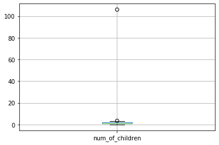

```python
# import pandas
import pandas as pd
# import matplotlib
import matplotlib.pyplot as plt
# import seaborn
import seaborn as sns
%matplotlib inline


a_data.boxplot(column =['num_of_children'])
```

```python
#Check Values in this column
a_data['num_of_children'].value_counts(dropna=False)
```

```
NaN      887
1.0       53
2.0       44
3.0        8
0.0        6
4.0        1
106.0      1
Name: num_of_children, dtype: int64
```

'num_of_children' has outlier - 106

```python
#Replace this outlier with 0
edit1 = {"num_of_children":{106 : 0}}
a_data.replace(edit1, inplace=True)
```

```python
#Check..
a_data['num_of_children'].value_counts(dropna=False)
```

```
NaN    887
1.0     53
2.0     44
3.0      8
0.0      7
4.0      1
Name: num_of_children, dtype: int64
```

###### handle num_of_adults

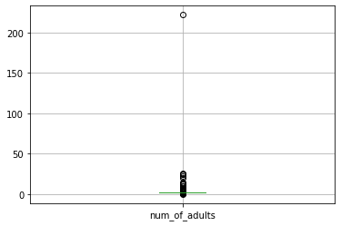

```python
#check boxplot
a_data.boxplot(column =['num_of_adults'])
```

```python
#Check values of this column
a_data['num_of_adults'].value_counts(dropna=False)
```

```
2.0      461
NaN      220
1.0      135
4.0       66
3.0       64
5.0       16
6.0       12
8.0        7
7.0        5
10.0       3
14.0       2
25.0       2
15.0       1
222.0      1
12.0       1
20.0       1
0.0        1
26.0       1
22.0       1
Name: num_of_adults, dtype: int64
```

'num_of_adults' has outlier 222 and has missing values

```python
edit = {"num_of_adults":{222.0 : 0}}
a_data.replace(edit, inplace=True)
```

```python
#check
a_data['num_of_adults'].value_counts(dropna=False)
```

```
2.0     461
NaN     220
1.0     135
4.0      66
3.0      64
5.0      16
6.0      12
8.0       7
7.0       5
10.0      3
0.0       2
25.0      2
14.0      2
22.0      1
12.0      1
20.0      1
26.0      1
15.0      1
Name: num_of_adults, dtype: int64
```

### #Handle missing data

###### handle 'num_of_children'

```python
#Check missings
a_data['num_of_children'].value_counts(dropna=False)
```

```
NaN    887
1.0     53
2.0     44
3.0      8
0.0      7
4.0      1
Name: num_of_children, dtype: int64
```

```python
#handle missing data in 'num_of_children', fill it by median
num_of_children_median = a_data['num_of_children'].median()

# Replace all the missing values in the num_of_children column with the median
a_data['num_of_children'] = a_data['num_of_children'].fillna(num_of_children_median)
```

```python
#check
a_data['num_of_children'].value_counts(dropna=False)
```

```
1.0    940
2.0     44
3.0      8
0.0      7
4.0      1
Name: num_of_children, dtype: int64
```

now clumn 'num_of_children' is cleaned

```python
#check..
a_data.info()
```

```
<class 'pandas.core.frame.DataFrame'>
Int64Index: 1000 entries, 0 to 999
Data columns (total 13 columns):
request_id         1000 non-null int64
confirmed          1000 non-null int64
client_id          1000 non-null int64
nation             1000 non-null object
arrival_date       974 non-null datetime64[ns]
departure_date     974 non-null datetime64[ns]
num_of_adults      780 non-null float64
num_of_children    1000 non-null float64
price              329 non-null float64
currency_id        329 non-null float64
adwords            1000 non-null int64
source_id          986 non-null float64
sub_id             1000 non-null int64
dtypes: datetime64[ns](2), float64(5), int64(5), object(1)
memory usage: 109.4+ KB
```

###### handle 'num_of_adults'

```python
#check missings
a_data['num_of_adults'].value_counts(dropna=False)
```

```
2.0     461
NaN     220
1.0     135
4.0      66
3.0      64
5.0      16
6.0      12
8.0       7
7.0       5
10.0      3
0.0       2
25.0      2
14.0      2
22.0      1
12.0      1
20.0      1
26.0      1
15.0      1
Name: num_of_adults, dtype: int64
```

```python
#handle missing data in 'num_of_adults', fill it by median
num_of_adults_median = a_data['num_of_adults'].median()

# Replace all the missing values in the num_of_adults column with the median
a_data['num_of_adults'] = a_data['num_of_adults'].fillna(num_of_adults_median)
```

```python
#check
a_data['num_of_adults'].value_counts(dropna=False)
```

```
2.0     681
1.0     135
4.0      66
3.0      64
5.0      16
6.0      12
8.0       7
7.0       5
10.0      3
14.0      2
25.0      2
0.0       2
15.0      1
12.0      1
20.0      1
26.0      1
22.0      1
Name: num_of_adults, dtype: int64
```

###### handle column 'price'

```python
#check missings
a_data['price'].value_counts(dropna=False)
```

```
NaN     671
12.0      7
56.0      7
20.0      6
33.0      6
       ...
17.0      1
37.0      1
79.0      1
70.0      1
26.0      1
Name: price, Length: 94, dtype: int64
```

```python
# Replace all the missing values in the price column with 0
a_data['price'] = a_data['price'].fillna(0)
```

```python
#check
a_data['price'].value_counts(dropna=False)
```

```
0.0     671
12.0      7
56.0      7
20.0      6
33.0      6
       ...
17.0      1
37.0      1
79.0      1
70.0      1
26.0      1
Name: price, Length: 94, dtype: int64
```

```python
#check..
a_data.describe()
```

|  | request_id | confirmed | client_id | num_of_adults | num_of_children | price | currency_id | adwords | source_id | sub_id |
| --- | --- | --- | --- | --- | --- | --- | --- | --- | --- | --- |
| count | 1.000000e+03 | 1000.000000 | 1.000000e+03 | 1000.0000 | 1000.00000 | 1000.000000 | 329.000000 | 1000.000000 | 986.000000 | 1000.000000 |
| mean | 5.112927e+08 | 0.325000 | 5.059396e+08 | 2.3990 | 1.05600 | 16.158000 | 2.006079 | 0.164000 | 42.561866 | 15.018000 |
| std | 2.840683e+08 | 0.468609 | 2.882389e+08 | 2.0337 | 0.29825 | 28.024639 | 0.728320 | 0.370461 | 44.400790 | 18.637033 |
| min | 1.350906e+06 | 0.000000 | 3.026870e+05 | 0.0000 | 0.00000 | 0.000000 | 1.000000 | 0.000000 | 1.000000 | 0.000000 |
| 25% | 2.671576e+08 | 0.000000 | 2.515670e+08 | 2.0000 | 1.00000 | 0.000000 | 2.000000 | 0.000000 | 1.000000 | 0.000000 |
| 50% | 5.190409e+08 | 0.000000 | 5.169784e+08 | 2.0000 | 1.00000 | 0.000000 | 2.000000 | 0.000000 | 29.000000 | 15.000000 |
| 75% | 7.548263e+08 | 1.000000 | 7.588429e+08 | 2.0000 | 1.00000 | 23.000000 | 2.000000 | 0.000000 | 87.000000 | 17.000000 |
| max | 9.988137e+08 | 1.000000 | 9.982175e+08 | 26.0000 | 4.00000 | 99.000000 | 4.000000 | 1.000000 | 225.000000 | 169.000000 |

###### handle column 'currency_id'

```python
#Check NANs
a_data['currency_id'].value_counts(dropna=False)
```

```
NaN    671
2.0    224
1.0     63
4.0     23
3.0     19
Name: currency_id, dtype: int64
```

```python
#handle missing data in 'currency_id', fill it with the most common currency
currency_id_common = 2.0
a_data['currency_id'] = a_data['currency_id'].fillna(currency_id_common)
```

```python
#check
a_data['currency_id'].value_counts()
```

```
2.0    895
1.0     63
4.0     23
3.0     19
Name: currency_id, dtype: int64
```

###### handle column 'source_id'

```python
#check values..
a_data['source_id'].value_counts(dropna=False)
```

```
1.0      302
29.0     109
93.0      68
2.0       60
105.0     37
65.0      30
87.0      30
6.0       26
74.0      22
81.0      20
89.0      20
7.0       18
41.0      18
99.0      17
77.0      16
66.0      15
NaN       14
5.0       14
101.0     14
73.0      13
4.0       12
90.0      11
56.0      10
94.0       9
133.0      8
23.0       7
12.0       6
57.0       6
127.0      5
9.0        5
91.0       5
97.0       5
145.0      4
102.0      4
106.0      4
75.0       4
59.0       3
103.0      3
197.0      2
82.0       2
95.0       2
79.0       2
47.0       2
58.0       1
199.0      1
215.0      1
155.0      1
209.0      1
185.0      1
213.0      1
153.0      1
217.0      1
63.0       1
225.0      1
37.0       1
69.0       1
80.0       1
88.0       1
161.0      1
Name: source_id, dtype: int64
```

```python
#handle missing data in 'source_id', fill it with the most common currency
source_id_common = 1.0
a_data['source_id'] = a_data['source_id'].fillna(source_id_common)
```

```python
#check ...
a_data['source_id'].value_counts(dropna=False)
```

```
1.0      316
29.0     109
93.0      68
2.0       60
105.0     37
65.0      30
87.0      30
6.0       26
74.0      22
81.0      20
89.0      20
7.0       18
41.0      18
99.0      17
77.0      16
66.0      15
5.0       14
101.0     14
73.0      13
4.0       12
90.0      11
56.0      10
94.0       9
133.0      8
23.0       7
57.0       6
12.0       6
127.0      5
9.0        5
91.0       5
97.0       5
145.0      4
102.0      4
106.0      4
75.0       4
59.0       3
103.0      3
197.0      2
82.0       2
95.0       2
79.0       2
47.0       2
58.0       1
199.0      1
215.0      1
155.0      1
209.0      1
185.0      1
213.0      1
153.0      1
217.0      1
63.0       1
225.0      1
37.0       1
69.0       1
80.0       1
88.0       1
161.0      1
Name: source_id, dtype: int64
```

###### handle columns 'arrival_date', 'departure_date'

```python
#check..
a_data.info()
```

```
<class 'pandas.core.frame.DataFrame'>
Int64Index: 1000 entries, 0 to 999
Data columns (total 13 columns):
request_id         1000 non-null int64
confirmed          1000 non-null int64
client_id          1000 non-null int64
nation             1000 non-null object
arrival_date       974 non-null datetime64[ns]
departure_date     974 non-null datetime64[ns]
num_of_adults      1000 non-null float64
num_of_children    1000 non-null float64
price              1000 non-null float64
currency_id        1000 non-null float64
adwords            1000 non-null int64
source_id          1000 non-null float64
sub_id             1000 non-null int64
dtypes: datetime64[ns](2), float64(5), int64(5), object(1)
memory usage: 109.4+ KB
```

```python
#check missing..
a_data['arrival_date'].value_counts(dropna=False)
```

```
NaT           26
2017-01-02     8
2013-11-01     5
2016-12-17     5
2017-04-12     4
              ..
2013-05-18     1
2013-10-04     1
2016-01-01     1
2013-09-19     1
2017-03-05     1
Name: arrival_date, Length: 746, dtype: int64
```

```python
#check missing..
a_data['departure_date'].value_counts(dropna=False)
```

```
NaT           26
2017-01-02     7
2017-12-31     5
2016-12-27     4
2017-12-02     4
              ..
2015-09-16     1
2017-01-07     1
2015-01-26     1
2017-02-15     1
2018-10-06     1
Name: departure_date, Length: 763, dtype: int64
```

###### these columns has just 26 missing data, it cannot be filled with any value because it gonna be outlier and it will be fine drop these missings

```python
#drop missing values in the dataset
cleaned_data = a_data.dropna()
```

```python
cleaned_data.info()
```

```
<class 'pandas.core.frame.DataFrame'>
Int64Index: 974 entries, 0 to 999
Data columns (total 13 columns):
request_id         974 non-null int64
confirmed          974 non-null int64
client_id          974 non-null int64
nation             974 non-null object
arrival_date       974 non-null datetime64[ns]
departure_date     974 non-null datetime64[ns]
num_of_adults      974 non-null float64
num_of_children    974 non-null float64
price              974 non-null float64
currency_id        974 non-null float64
adwords            974 non-null int64
source_id          974 non-null float64
sub_id             974 non-null int64
dtypes: datetime64[ns](2), float64(5), int64(5), object(1)
memory usage: 106.5+ KB
```

#### now the dataset is cleaned

## 5)Add Columns/Tranformation

```python
#create new columns
cleaned_data['duration'] = cleaned_data['departure_date'] -  cleaned_data['arrival_date']
```

```python
#create new columns
cleaned_data['family_members'] = cleaned_data['num_of_adults'] +  cleaned_data['num_of_children']
```

```python
cleaned_data.head()
```

|  | request_id | confirmed | client_id | nation | arrival_date | departure_date | num_of_adults | num_of_children | price | currency_id | adwords | source_id | sub_id | duration | family_members |
| --- | --- | --- | --- | --- | --- | --- | --- | --- | --- | --- | --- | --- | --- | --- | --- |
| 0 | 806181796 | 0 | 123420484 | Germany | 2016-12-26 | 2017-01-02 | 2.0 | 1.0 | 0.0 | 2.0 | 0 | 99.0 | 0 | 7 days | 3.0 |
| 1 | 38700156 | 0 | 839911394 | Chile | 2012-10-17 | 2012-10-24 | 2.0 | 1.0 | 0.0 | 2.0 | 0 | 29.0 | 17 | 7 days | 3.0 |
| 2 | 992039421 | 0 | 62928855 | United Kingdom | 2016-05-15 | 2016-05-18 | 5.0 | 1.0 | 0.0 | 2.0 | 0 | 1.0 | 0 | 3 days | 6.0 |
| 3 | 625114613 | 0 | 374952733 | Argentina | 2018-03-17 | 2018-03-17 | 2.0 | 1.0 | 0.0 | 2.0 | 0 | 94.0 | 8 | 0 days | 3.0 |
| 4 | 647445179 | 0 | 600861297 | Chile | 2013-01-13 | 2013-01-13 | 2.0 | 1.0 | 0.0 | 2.0 | 0 | 5.0 | 0 | 0 days | 3.0 |

```python
#convert duration type into 'timedelta64[D]' instead of 'timedelta64[ns]'
cleaned_data['duration'] =  cleaned_data['duration'].astype('timedelta64[D]')
```

```python
cleaned_data.info()
```

```
<class 'pandas.core.frame.DataFrame'>
Int64Index: 974 entries, 0 to 999
Data columns (total 15 columns):
request_id         974 non-null int64
confirmed          974 non-null int64
client_id          974 non-null int64
nation             974 non-null object
arrival_date       974 non-null datetime64[ns]
departure_date     974 non-null datetime64[ns]
num_of_adults      974 non-null float64
num_of_children    974 non-null float64
price              974 non-null float64
currency_id        974 non-null float64
adwords            974 non-null int64
source_id          974 non-null float64
sub_id             974 non-null int64
duration           974 non-null float64
family_members     974 non-null float64
dtypes: datetime64[ns](2), float64(7), int64(5), object(1)
memory usage: 121.8+ KB
```

```python
cleaned_data.describe()
```

|  | request_id | confirmed | client_id | num_of_adults | num_of_children | price | currency_id | adwords | source_id | sub_id | duration | family_members |
| --- | --- | --- | --- | --- | --- | --- | --- | --- | --- | --- | --- | --- |
| count | 9.740000e+02 | 974.000000 | 9.740000e+02 | 974.000000 | 974.000000 | 974.000000 | 974.000000 | 974.000000 | 974.000000 | 974.000000 | 974.000000 | 974.000000 |
| mean | 5.125343e+08 | 0.333676 | 5.044711e+08 | 2.409651 | 1.057495 | 16.589322 | 2.002053 | 0.168378 | 42.765914 | 15.366530 | 4.207392 | 3.467146 |
| std | 2.843160e+08 | 0.471768 | 2.878985e+08 | 2.059632 | 0.302066 | 28.270201 | 0.422876 | 0.374394 | 44.357774 | 18.739139 | 13.916286 | 2.090071 |
| min | 1.350906e+06 | 0.000000 | 3.026870e+05 | 0.000000 | 0.000000 | 0.000000 | 1.000000 | 0.000000 | 1.000000 | 0.000000 | -352.000000 | 0.000000 |
| 25% | 2.677457e+08 | 0.000000 | 2.518775e+08 | 2.000000 | 1.000000 | 0.000000 | 2.000000 | 0.000000 | 1.000000 | 0.000000 | 0.000000 | 3.000000 |
| 50% | 5.199004e+08 | 0.000000 | 5.161461e+08 | 2.000000 | 1.000000 | 0.000000 | 2.000000 | 0.000000 | 29.000000 | 16.000000 | 3.000000 | 3.000000 |
| 75% | 7.549827e+08 | 1.000000 | 7.584401e+08 | 2.000000 | 1.000000 | 25.750000 | 2.000000 | 0.000000 | 87.000000 | 17.000000 | 7.000000 | 3.000000 |
| max | 9.988137e+08 | 1.000000 | 9.982175e+08 | 26.000000 | 4.000000 | 99.000000 | 4.000000 | 1.000000 | 225.000000 | 169.000000 | 153.000000 | 27.000000 |

here maybe there is at least one outlier(-352) in duration column...let's check deeper

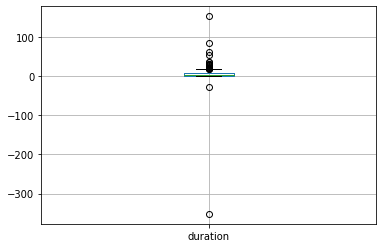

```python
#check boxplot
cleaned_data.boxplot(column =['duration'])
```

# Here i can see there are two outlier in duration column...let's handle them

```python
#let's check the values
cleaned_data['duration'].value_counts(dropna=False)
```

```
 0.0      390
 7.0       96
 3.0       70
 4.0       54
 1.0       48
 8.0       42
 6.0       37
 5.0       35
 9.0       34
 10.0      28
 11.0      27
 2.0       26
 14.0      24
 12.0      14
 15.0      10
 13.0      10
 16.0       4
 20.0       3
 17.0       3
 30.0       3
 29.0       2
 19.0       2
 36.0       1
 84.0       1
 62.0       1
 21.0       1
-28.0       1
-352.0      1
 26.0       1
 22.0       1
 37.0       1
 54.0       1
 24.0       1
 153.0      1
Name: duration, dtype: int64
```

```python
#handle first outlier
edit1 = {"duration":{-352.0 : cleaned_data['duration'].median()}}
cleaned_data.replace(edit1, inplace=True)
```

```python
#handle second outlier
edit1 = {"duration":{-28.0 : cleaned_data['duration'].median()}}
cleaned_data.replace(edit1, inplace=True)
```

```python
cleaned_data.describe()
```

|  | request_id | confirmed | client_id | num_of_adults | num_of_children | price | currency_id | adwords | source_id | sub_id | duration | family_members |
| --- | --- | --- | --- | --- | --- | --- | --- | --- | --- | --- | --- | --- |
| count | 9.740000e+02 | 974.000000 | 9.740000e+02 | 974.000000 | 974.000000 | 974.000000 | 974.000000 | 974.000000 | 974.000000 | 974.000000 | 974.000000 | 974.000000 |
| mean | 5.125343e+08 | 0.333676 | 5.044711e+08 | 2.409651 | 1.057495 | 16.589322 | 2.002053 | 0.168378 | 42.765914 | 15.366530 | 4.603696 | 3.467146 |
| std | 2.843160e+08 | 0.471768 | 2.878985e+08 | 2.059632 | 0.302066 | 28.270201 | 0.422876 | 0.374394 | 44.357774 | 18.739139 | 7.876424 | 2.090071 |
| min | 1.350906e+06 | 0.000000 | 3.026870e+05 | 0.000000 | 0.000000 | 0.000000 | 1.000000 | 0.000000 | 1.000000 | 0.000000 | 0.000000 | 0.000000 |
| 25% | 2.677457e+08 | 0.000000 | 2.518775e+08 | 2.000000 | 1.000000 | 0.000000 | 2.000000 | 0.000000 | 1.000000 | 0.000000 | 0.000000 | 3.000000 |
| 50% | 5.199004e+08 | 0.000000 | 5.161461e+08 | 2.000000 | 1.000000 | 0.000000 | 2.000000 | 0.000000 | 29.000000 | 16.000000 | 3.000000 | 3.000000 |
| 75% | 7.549827e+08 | 1.000000 | 7.584401e+08 | 2.000000 | 1.000000 | 25.750000 | 2.000000 | 0.000000 | 87.000000 | 17.000000 | 7.000000 | 3.000000 |
| max | 9.988137e+08 | 1.000000 | 9.982175e+08 | 26.000000 | 4.000000 | 99.000000 | 4.000000 | 1.000000 | 225.000000 | 169.000000 | 153.000000 | 27.000000 |

#### Save Cleaned Data

```python
#Save cleaned data in Ecxel file 'cleaneddata.csv'
```

```python
#cleaned_data.to_csv(r'E:\MoneyFellows Task-Exam\my job\cleaneddata.csv', index = False)
```

# ............................................................................................................................

## 6) Modeling

Now I'm gonna build a model allow us to detect the Potential candidate(confirm) based on the other Features

### Import data and assess it

```python
#import pandas
import pandas as pd
#data file path
path = "E:\MoneyFellows Task-Exam\my job\cleaneddata.csv"
#import the CSV file
data_model= pd.read_csv(path)
data_model.head()
```

|  | request_id | confirmed | client_id | nation | arrival_date | departure_date | num_of_adults | num_of_children | price | currency_id | adwords | source_id | sub_id | duration | family_members |
| --- | --- | --- | --- | --- | --- | --- | --- | --- | --- | --- | --- | --- | --- | --- | --- |
| 0 | 806181796 | 0 | 123420484 | Germany | 2016-12-26 | 2017-01-02 | 2.0 | 1.0 | 0.0 | 2.0 | 0 | 99.0 | 0 | 7.0 | 3.0 |
| 1 | 38700156 | 0 | 839911394 | Chile | 2012-10-17 | 2012-10-24 | 2.0 | 1.0 | 0.0 | 2.0 | 0 | 29.0 | 17 | 7.0 | 3.0 |
| 2 | 992039421 | 0 | 62928855 | United Kingdom | 2016-05-15 | 2016-05-18 | 5.0 | 1.0 | 0.0 | 2.0 | 0 | 1.0 | 0 | 3.0 | 6.0 |
| 3 | 625114613 | 0 | 374952733 | Argentina | 2018-03-17 | 2018-03-17 | 2.0 | 1.0 | 0.0 | 2.0 | 0 | 94.0 | 8 | 0.0 | 3.0 |
| 4 | 647445179 | 0 | 600861297 | Chile | 2013-01-13 | 2013-01-13 | 2.0 | 1.0 | 0.0 | 2.0 | 0 | 5.0 | 0 | 0.0 | 3.0 |

```python
#let's check
data_model.info()
```

```
<class 'pandas.core.frame.DataFrame'>
RangeIndex: 974 entries, 0 to 973
Data columns (total 15 columns):
request_id         974 non-null int64
confirmed          974 non-null int64
client_id          974 non-null int64
nation             974 non-null object
arrival_date       974 non-null object
departure_date     974 non-null object
num_of_adults      974 non-null float64
num_of_children    974 non-null float64
price              974 non-null float64
currency_id        974 non-null float64
adwords            974 non-null int64
source_id          974 non-null float64
sub_id             974 non-null int64
duration           974 non-null float64
family_members     974 non-null float64
dtypes: float64(7), int64(5), object(3)
memory usage: 114.3+ KB
```

### Selecting The Target AND Features of the model

```python
#check columns
data_model.columns
```

```
Index(['request_id', 'confirmed', 'client_id', 'nation', 'arrival_date',
       'departure_date', 'num_of_adults', 'num_of_children', 'price',
       'currency_id', 'adwords', 'source_id', 'sub_id', 'duration',
       'family_members'],
      dtype='object')
```

```python
#selecting 'features' variables
data_features = ['nation', 'duration',
        'num_of_adults', 'num_of_children', 'price',
       'currency_id', 'adwords', 'source_id', 'sub_id', 'family_members']
```

```python
data_targets = ['confirmed']
```

```python
features = data_model[data_features]
```

```python
target = data_model[data_targets]
```

```python
y = target
```